# **House Prices**

**1. Introduction**  
**1.1 Datasets and features**  
**1.2 Methodology**  
**1.3 Import libraries and data**  
**1.4 Functions**

**2. Exploratory Data Analysis**  
**2.1 General dataset features**  
**2.2 Missing values**  
**2.3 Sale price**  
2.3.1 Statistical details  
2.3.2 Relation with other features  
**2.4 Features selection**  
2.4.1 Numerical features  
2.4.2 Categorical features selection  
2.4.3 Numerical and categorical feature importance  
**2.5 Outliers**  
2.5.1 Sale price univariate analysis  
2.5.2 Bivariate analysis  
**2.6 Normality, Homoscedasticity and linearity**  
2.6.1 Normality  
2.6.2 Homoscedasticity

**3. Predictive model: Linear regression**

**4. Test set**  
**4.1 Fixing data**  
**4.2 Apply the model**  
**4.3 Submission file**

## **1. Introduction**

This proyect is part of the Kaggle competition [House Prices - Advanced Regression Techniques](https://www.kaggle.com/competitions/house-prices-advanced-regression-techniques/overview). Our task is to predict the price of a set of houses from the Ames Housing dataset compiled by Dean De Cock.

### **1.1 Datasets and features**

In this proyect we use two datasets:

- *train.csv*: It is a set with 1460 houses, 79 features and sale price for each house.
- *test.csv*: It is a set with 1459 houses and the same 79 features as in the previous dataset.

### **1.2 Methodology**

As our datasets have a huge number of features, we will perform feature selection. To do so, we will use statistical methods and also machine learning methods. We will also check for normality, homoscedasticity and linearity in numerical features beafore applying a predictive machine learning model. Finally, we will use a regularized linear regression model to make our predictions.

### **1.3 Import libraries and data**

```python
import pandas as pd
import numpy as np
import matplotlib.pyplot as plt
import seaborn as sns

from sklearn.feature_selection import f_classif
from sklearn.preprocessing import OrdinalEncoder
from sklearn.feature_selection import SelectKBest
from sklearn.tree import DecisionTreeRegressor
from sklearn.linear_model import LinearRegression, Ridge
from sklearn.ensemble import RandomForestRegressor
from sklearn.preprocessing import StandardScaler
from sklearn.model_selection import KFold
from sklearn.metrics import mean_squared_error
from sklearn.preprocessing import StandardScaler
from sklearn.preprocessing import PolynomialFeatures

import scipy.stats as stats

from xgboost import XGBRegressor


import warnings
warnings.simplefilter('ignore')
```

```python
# Load datasets
train = pd.read_csv('./data/train.csv')
test = pd.read_csv('./data/test.csv')
```

### **1.4 Functions**

```python
def general_info(data, title: str, cols_disp=10, max_cols=100):
    print(title)
    print('-----------------------------------------------')

    # Shape, duplicates and null values
    print('Shape:', data.shape)
    print('Duplicates:', sum(data.duplicated()))
    print('Null values:', sum(data.isnull().sum()))

    # Name of columns
    print('\nColumns:')
    i_0 = 0
    for i in range(len(data.columns)):

        if (i % cols_disp == 0) & (i != 0):
            i_cols = data.columns[i_0:i]
            print(f"{i_0}-{i}:", ', '.join([feature for feature in i_cols]))
            i_0 = i

        elif (i == len(data.columns) - 1) or (i >= max_cols):
            i_cols = data.columns[i_0 :]
            print(f"{i_0}-{i}:", ', '.join([feature for feature in i_cols]))
            break

        else:
            continue

    # Number of categorical features
    numerical_features = data.dtypes != 'object'
    print('\nNumerical features:', numerical_features.sum())
    print('Categorical features:', data.shape[1] - numerical_features.sum())

    # Additional features info
    print('\n Data info:')
    print(data.info())

def missing_data(df):
    '''Create a dataframe with information on missing data'''
    # NaN values
    na = df.isna().sum().sort_values(ascending=False)
    na_percent = (df.isna().sum()/df.isna().count()).sort_values(ascending=False)

    # Null values
    null = df.isnull().sum().sort_values(ascending=False)
    null_percent = (df.isnull().sum()/df.isnull().count()).sort_values(ascending=False)

    # Concatenate results
    missing = pd.concat([na, na_percent, null, null_percent], axis=1,
                        keys=['Total_NaN', 'Percent_NaN', 'Total_null', 'Percent_null'])
    return missing


def prepare_inputs(X_train, X_test=False):
    '''Performs ordinal encoding for categorical data'''
    oe = OrdinalEncoder()
    oe.fit(X_train)
    if X_test:
        X_train_enc = oe.transform(X_train)
        X_test_enc = oe.transform(X_test)
        return X_train_enc, X_test_enc
    else:
        X_train_enc = oe.transform(X_train)
        return X_train_enc

def DT_feature_importance(model, X, y, ax, features, title):
    '''This function returns a barplot with the importance of
    the different features used in a Decission tree based ML model'''

    # train the model
    model.fit(X, y)

    # Get importance values
    importance = model.feature_importances_

    # Create dataframe with the importance information
    importance = pd.DataFrame(data=importance, index=list(X.columns), columns=['importance'])

    # Plot
    ax.bar(importance.index, importance['importance'])
    ax.set_title(title)
    ax.set_xticklabels(features, rotation=90);


def hist_normal(data):
    ''' This function plots a histogram with the variable distribution
    and superpose it with a normal probability function with the same
    mean and standard deviation than the data'''

    # Fit normal distribution parameters mean and standard deviation to the data:
    mu, std = stats.norm.fit(data)

    # Plot the histogram.
    fig = plt.figure()
    sns.distplot(data, color='tab:blue')

    # Plot the PDF.
    xmin, xmax = plt.xlim()
    x = np.linspace(xmin, xmax, 100)
    p = stats.norm.pdf(x, mu, std)

    plt.plot(x, p, 'k', linewidth=2)
```

## **2. Exploratory Data Analysis**

### **2.1 General dataset features**

We will start looking at the general properties of our training set

```python
general_info(train, 'Housing dataset', cols_disp=10)
```

```
Housing dataset
-----------------------------------------------
Shape: (1460, 81)
Duplicates: 0
Null values: 7829

Columns:
0-10: Id, MSSubClass, MSZoning, LotFrontage, LotArea, Street, Alley, LotShape, LandContour, Utilities
10-20: LotConfig, LandSlope, Neighborhood, Condition1, Condition2, BldgType, HouseStyle, OverallQual, OverallCond, YearBuilt
20-30: YearRemodAdd, RoofStyle, RoofMatl, Exterior1st, Exterior2nd, MasVnrType, MasVnrArea, ExterQual, ExterCond, Foundation
30-40: BsmtQual, BsmtCond, BsmtExposure, BsmtFinType1, BsmtFinSF1, BsmtFinType2, BsmtFinSF2, BsmtUnfSF, TotalBsmtSF, Heating
40-50: HeatingQC, CentralAir, Electrical, 1stFlrSF, 2ndFlrSF, LowQualFinSF, GrLivArea, BsmtFullBath, BsmtHalfBath, FullBath
50-60: HalfBath, BedroomAbvGr, KitchenAbvGr, KitchenQual, TotRmsAbvGrd, Functional, Fireplaces, FireplaceQu, GarageType, GarageYrBlt
60-70: GarageFinish, GarageCars, GarageArea, GarageQual, GarageCond, PavedDrive, WoodDeckSF, OpenPorchSF, EnclosedPorch, 3SsnPorch
70-80: ScreenPorch, PoolArea, PoolQC, Fence, MiscFeature, MiscVal, MoSold, YrSold, SaleType, SaleCondition
```

[output cut: 94 more lines]

We have a dataset with many features, numerical and categorical. We will have to perform an important features selection task.

There are no duplicates and we will have to deal with missing data.

### **2.2 Missing values**

Let us look deeper into missing data.

```python
missing_data(train)
```

|  | Total_NaN | Percent_NaN | Total_null | Percent_null |
| --- | --- | --- | --- | --- |
| PoolQC | 1453 | 0.995205 | 1453 | 0.995205 |
| MiscFeature | 1406 | 0.963014 | 1406 | 0.963014 |
| Alley | 1369 | 0.937671 | 1369 | 0.937671 |
| Fence | 1179 | 0.807534 | 1179 | 0.807534 |
| MasVnrType | 872 | 0.597260 | 872 | 0.597260 |
| ... | ... | ... | ... | ... |
| ExterQual | 0 | 0.000000 | 0 | 0.000000 |
| Exterior2nd | 0 | 0.000000 | 0 | 0.000000 |
| Exterior1st | 0 | 0.000000 | 0 | 0.000000 |
| RoofMatl | 0 | 0.000000 | 0 | 0.000000 |
| SalePrice | 0 | 0.000000 | 0 | 0.000000 |

81 rows × 4 columns

The features with a high percentage of missing values (over 15%) correspond to features that we do not consider them very important, and therefore will be deleted.

We also see some missing data for garage and basement information, and a few of masonry and electrical information.

The missing data in garage and basement possibly they refer to houses without garage or basement. Let us explore this.

We will start looking at houses with no basement.

```python
no_bsmt = train[train['TotalBsmtSF'] == 0][['TotalBsmtSF', 'BsmtQual', 'BsmtCond', 'BsmtFinType1', 'BsmtFinType2', 'BsmtExposure']]
print(no_bsmt)
print(no_bsmt.shape)
```

```
      TotalBsmtSF BsmtQual BsmtCond BsmtFinType1 BsmtFinType2 BsmtExposure
17              0      NaN      NaN          NaN          NaN          NaN
39              0      NaN      NaN          NaN          NaN          NaN
90              0      NaN      NaN          NaN          NaN          NaN
102             0      NaN      NaN          NaN          NaN          NaN
156             0      NaN      NaN          NaN          NaN          NaN
182             0      NaN      NaN          NaN          NaN          NaN
259             0      NaN      NaN          NaN          NaN          NaN
342             0      NaN      NaN          NaN          NaN          NaN
362             0      NaN      NaN          NaN          NaN          NaN
371             0      NaN      NaN          NaN          NaN          NaN
392             0      NaN      NaN          NaN          NaN          NaN
520             0      NaN      NaN          NaN          NaN          NaN
532             0      NaN      NaN          NaN          NaN          NaN
533             0      NaN      NaN          NaN          NaN          NaN
```

[output cut: 24 more lines]

As we thought, the missing values for basement information correspond to houses with no basement. We fill this values with 'NA'.

```python
mask = train['TotalBsmtSF'] == 0
train.loc[mask, ['BsmtQual', 'BsmtCond', 'BsmtFinType1', 'BsmtFinType2', 'BsmtExposure']] = train.loc[mask, ['BsmtQual', 'BsmtCond', 'BsmtFinType1', 'BsmtFinType2', 'BsmtExposure']].fillna('NA')
```

Now we look at houses with no garage.

```python
no_garage = train[train['GarageArea'] == 0].iloc[:, [58, 59, 60, 61, 62, 63, 64]]
print(no_garage)
print(no_garage.shape)
```

```
     GarageType  GarageYrBlt GarageFinish  GarageCars  GarageArea GarageQual  \
39          NaN          NaN          NaN           0           0        NaN
48          NaN          NaN          NaN           0           0        NaN
78          NaN          NaN          NaN           0           0        NaN
88          NaN          NaN          NaN           0           0        NaN
89          NaN          NaN          NaN           0           0        NaN
...         ...          ...          ...         ...         ...        ...
1349        NaN          NaN          NaN           0           0        NaN
1407        NaN          NaN          NaN           0           0        NaN
1449        NaN          NaN          NaN           0           0        NaN
1450        NaN          NaN          NaN           0           0        NaN
1453        NaN          NaN          NaN           0           0        NaN

     GarageCond
39          NaN
48          NaN
78          NaN
88          NaN
89          NaN
...         ...
1349        NaN
1407        NaN
1449        NaN
1450        NaN
1453        NaN

[81 rows x 7 columns]
(81, 7)
```

The 81 missing values correspond to houses without garage. We replace these data with 'NA'

```python
train.iloc[:, [58, 59, 60, 61, 62, 63, 64]] = train.fillna('NA').iloc[:, [58, 59, 60, 61, 62, 63, 64]]
```

Finally we drop columns with a percentage of missing values over 15%.

```python
train.drop(columns=['PoolQC', 'MiscFeature', 'Alley', 'Fence', 'MasVnrType', 'FireplaceQu', 'LotFrontage'], inplace=True)
```

We look again at the missing values

```python
missing_data(train).head(10)
```

|  | Total_NaN | Percent_NaN | Total_null | Percent_null |
| --- | --- | --- | --- | --- |
| MasVnrArea | 8 | 0.005479 | 8 | 0.005479 |
| BsmtExposure | 1 | 0.000685 | 1 | 0.000685 |
| BsmtFinType2 | 1 | 0.000685 | 1 | 0.000685 |
| Electrical | 1 | 0.000685 | 1 | 0.000685 |
| BedroomAbvGr | 0 | 0.000000 | 0 | 0.000000 |
| Fireplaces | 0 | 0.000000 | 0 | 0.000000 |
| Functional | 0 | 0.000000 | 0 | 0.000000 |
| TotRmsAbvGrd | 0 | 0.000000 | 0 | 0.000000 |
| KitchenQual | 0 | 0.000000 | 0 | 0.000000 |
| KitchenAbvGr | 0 | 0.000000 | 0 | 0.000000 |

We can drop the remaining missing data

```python
# Drop missing data
train.dropna(inplace=True)

# assert no missing data
assert train.isnull().sum().sum() == 0
```

### **2.3 Sale price**

We will try to get to know better our target feature.

#### 2.3.1 Statistical details

We start looking at the statistical details.

```
count      1449.000000
mean     180544.563147
std       79319.721026
min       34900.000000
25%      129900.000000
50%      162000.000000
75%      214000.000000
max      755000.000000
Name: SalePrice, dtype: float64
```

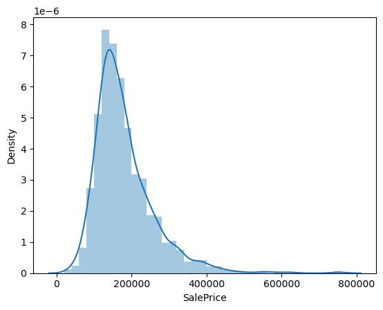

```python
# Statistical information
print(train['SalePrice'].describe())

# Distribution
step = 20000
bins = np.arange(0, train['SalePrice'].max() + step, step)
sns.distplot(train['SalePrice'], bins = bins)
```

There are no null values.

In the distribution we apreciate that it **deviates from normal distribution**, **shows peakedness** and **has positive skewedness**.

We confirm our observations looking at the skewness and kurtosis values.

```python
print(f"Skewness: {train['SalePrice'].skew():.3f}")
print(f"Kurtosis: {train['SalePrice'].kurt():.3f}")
```

```
Skewness: 1.887
Kurtosis: 6.588
```

#### 2.3.2 Relation with other features

In this sections we want to see how 'SalePrice' relates with the other features. We have too many features to look at all of them, so we will focus on those that we think that can have the biggest influence on sale price.

We will start by the ground living area.

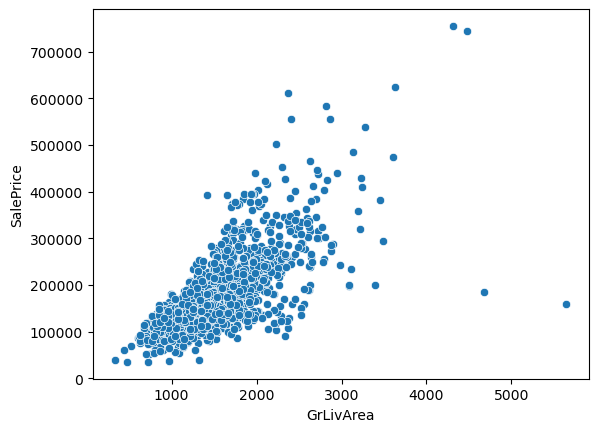

```python
var = 'GrLivArea'
sns.scatterplot(data=train, x=var, y='SalePrice');
```

We see a linear relation.

Now we look at the total basement squarefeets.

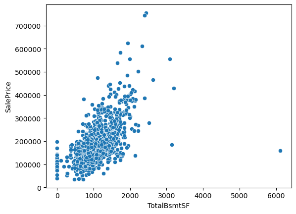

```python
var = 'TotalBsmtSF'
sns.scatterplot(data=train, x=var, y='SalePrice');
```

We see also a strong linear relation. We observe a line of cero values which correspond to houses without basement.

We follow with overall quality.

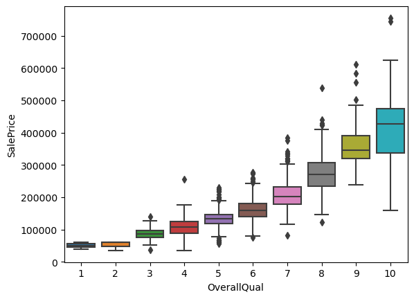

```python
var = 'OverallQual'
sns.boxplot(data=train, x=var, y='SalePrice');
```

We observe an exponential growth.

And what about the year of construction.

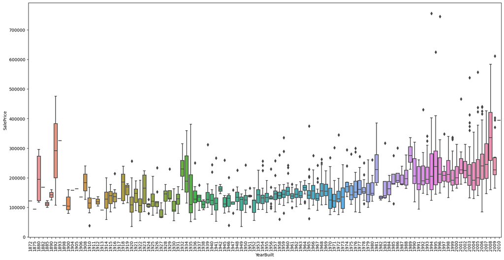

```python
var = 'YearBuilt'
plt.figure(figsize=[20, 10])
sns.boxplot(data=train, x=var, y='SalePrice')
plt.xticks(rotation=90);
```

We do not see a strong tendency, but in general the price increase for newer constructions.

We do not know if the sale price accounts for inflation changes over the years. We look at the year of sale range to try to clarify this.

```python
train['YrSold'].describe()
```

```
count    1449.000000
mean     2007.815735
std         1.329074
min      2006.000000
25%      2007.000000
50%      2008.000000
75%      2009.000000
max      2010.000000
Name: YrSold, dtype: float64
```

All houses were sold between 2006 and 2010. There should be no big changes in inflation and we can assume the prices as constants.

## **2.4 Features selection**

### 2.4.1 Numerical features

We start with numerical features. We plot the correlation values between features.

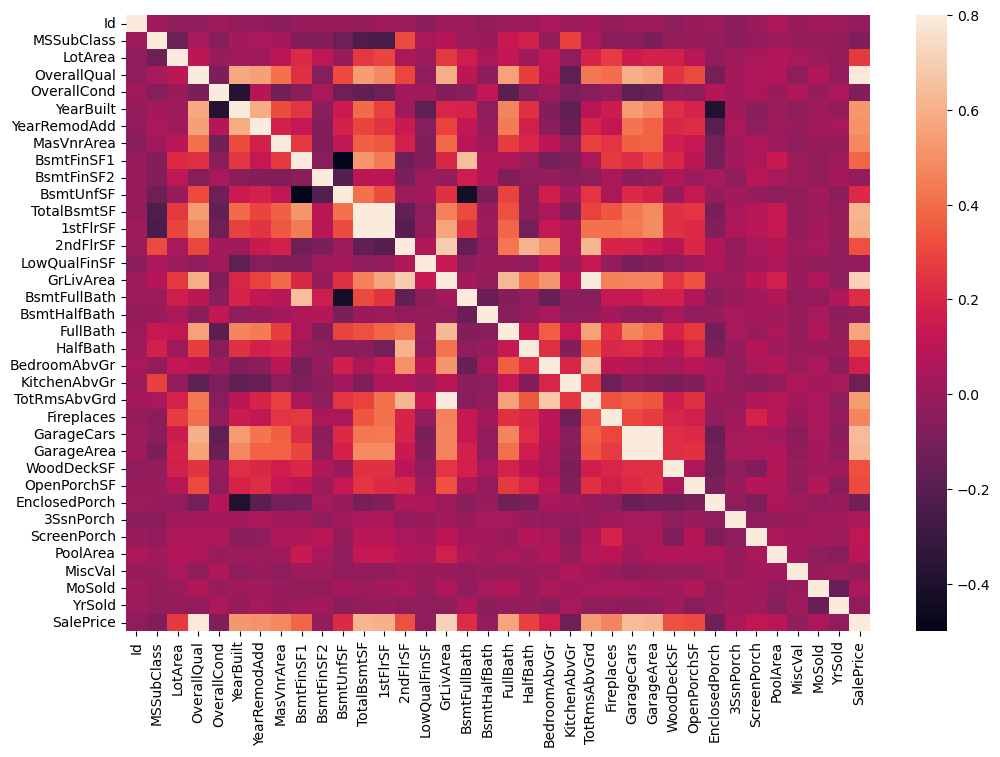

```python
corrmat = train.corr(numeric_only=True)
plt.figure(figsize=[12, 8])
sns.heatmap(data = corrmat, vmax=0.8, cmap='rocket')
```

It is interesting to note the correlation between *TotalBsmtSF* and *1stFlrSF*, and the *GarageX* variables.

The features which are more correlated to the Sale price are: *OverallQual, TotalBsmtSF, 1stFlrSF, GrLivArea, GarageCars and GarageArea*

We explore more in detail the features with the highest correlations.

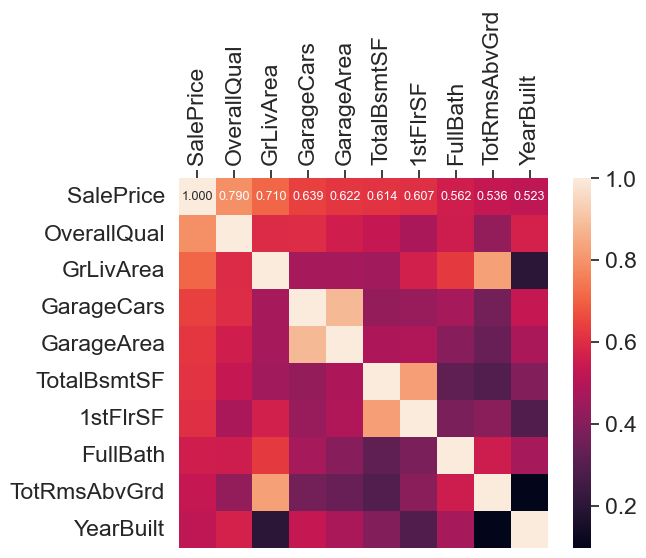

```python
k = 10
cols = corrmat.nlargest(k, 'SalePrice')['SalePrice'].index
cm = train[cols].corr()

sns.set(font_scale=1.5)
ax = sns.heatmap(cm, cbar=True, annot=True, square=True, fmt='.3f', annot_kws={'size':9})
ax.xaxis.tick_top()
plt.xticks(rotation=90);
```

We have some features which are strongly correlated, namely: *GarageCars* and *GarageArea*; *TotalBsmtSF* and *1stFlrSF*; *TotRmsAbvGrd* and *GrLivArea*.

Therefore, from these features we will keep only one and this will be the one which has the highest correlation with the sale price.

> We keep the numerical features: *OverallQual*, *GrLivArea*, *GarageCars*, *TotalBsmtSF*, *FullBath* and *YearBuilt*

```python
num_cols = ['SalePrice', 'OverallQual', 'GrLivArea', 'GarageCars', 'TotalBsmtSF', 'FullBath', 'YearBuilt']
```

We have a general look at the relations between these features

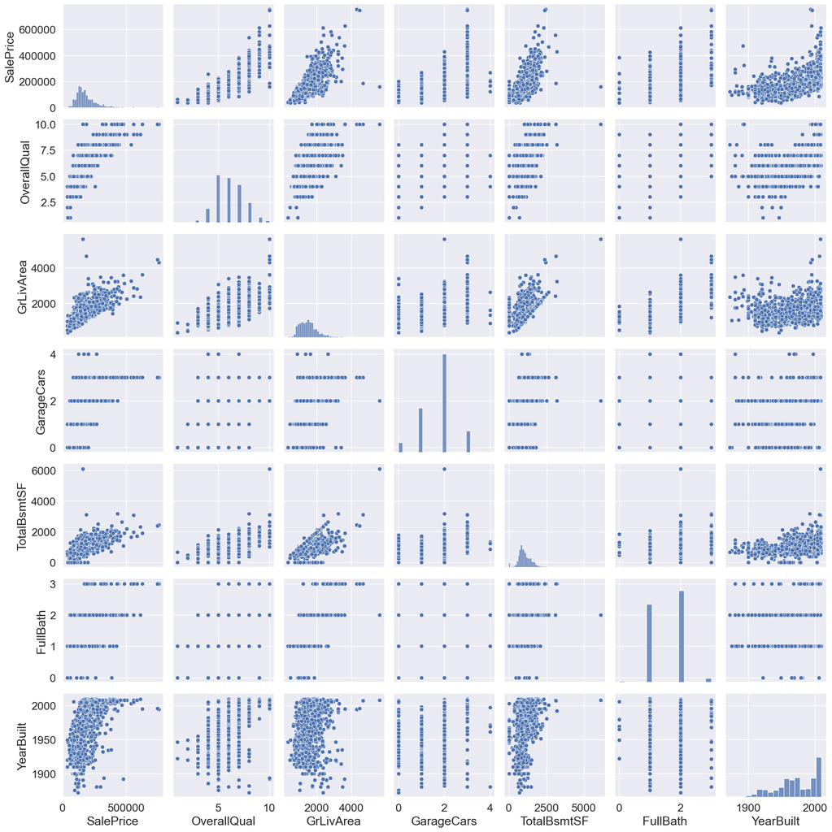

```python
sns.pairplot(train[num_cols], size=2.5);
```

We see some exponential growth in the sale price with the year of construction. And we also see an interesting line in the plot between 'TotalBsmtSF' and 'GrLivArea' which seem to be a result of the fact that it is very unlikely to find a house with a basement bigger than the ground living area.

### 2.4.2 Categorical features selection

We will use the f-test to analyse the relation between our categorical values and the numerical value 'SalePrice'.

To apply the f-test we need to encode our categorical variables and there can not be any missing values.

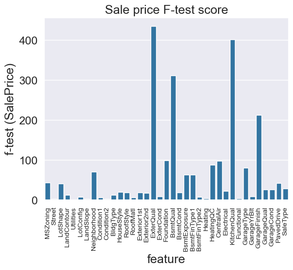

```python
# List with categorical features
corr_cols = list(corrmat.columns)
all_columns = list(train.columns)
cat_cols = [ele for ele in all_columns if ele not in corr_cols]

# Dataset with categorical features
train_cat = train[cat_cols]

# Ensure datatypes
train_cat = train_cat.astype(str)

# Ordinal encoding
train_cat_enc = prepare_inputs(train_cat)

# Compute f-test por feature-SalePrice pairs
f_test_values = []
for i in range(len(train_cat.columns)):
    f, _ = f_classif(train['SalePrice'].values.reshape(-1, 1), train_cat_enc[:, i])
    f_test_values.append(float(f))

# Create dataframe with f-test scores
f_test = pd.DataFrame({'feature':train_cat.columns, 'f-test (SalePrice)': f_test_values})
f_test.drop(index=37, inplace=True)

# Plot results
sns.barplot(data=f_test, y='f-test (SalePrice)', x='feature', color='tab:blue')
plt.xticks(rotation=90, fontsize=10)
plt.title('Sale price F-test score');
```

We keep the features with the higher f-test values

```python
cat_cols = ['ExterQual', 'BsmtQual', 'KitchenQual', 'GarageFinish']
```

### 2.4.3 Numerical and categorical feature importance

In this section we compare the importance given by different ML models to all the selected features.

```python
# Keep only features selected
selected_cols = num_cols + cat_cols
df_train = train[selected_cols]

# Separate X and y
y = df_train['SalePrice']
X = df_train.drop('SalePrice', axis=1)

# Ordinal encoding specifying categories order
X_enc = X.copy()
oe = OrdinalEncoder(categories=[['Fa','TA', 'Gd', 'Ex'], ['NA','Po','Fa','TA', 'Gd', 'Ex'], ['Po','Fa','TA', 'Gd', 'Ex'], ['NA', 'Unf', 'RFn', 'Fin']])
X_enc[['ExterQual', 'BsmtQual', 'KitchenQual', 'GarageFinish']] = oe.fit_transform(X_enc[['ExterQual', 'BsmtQual', 'KitchenQual', 'GarageFinish']])
```

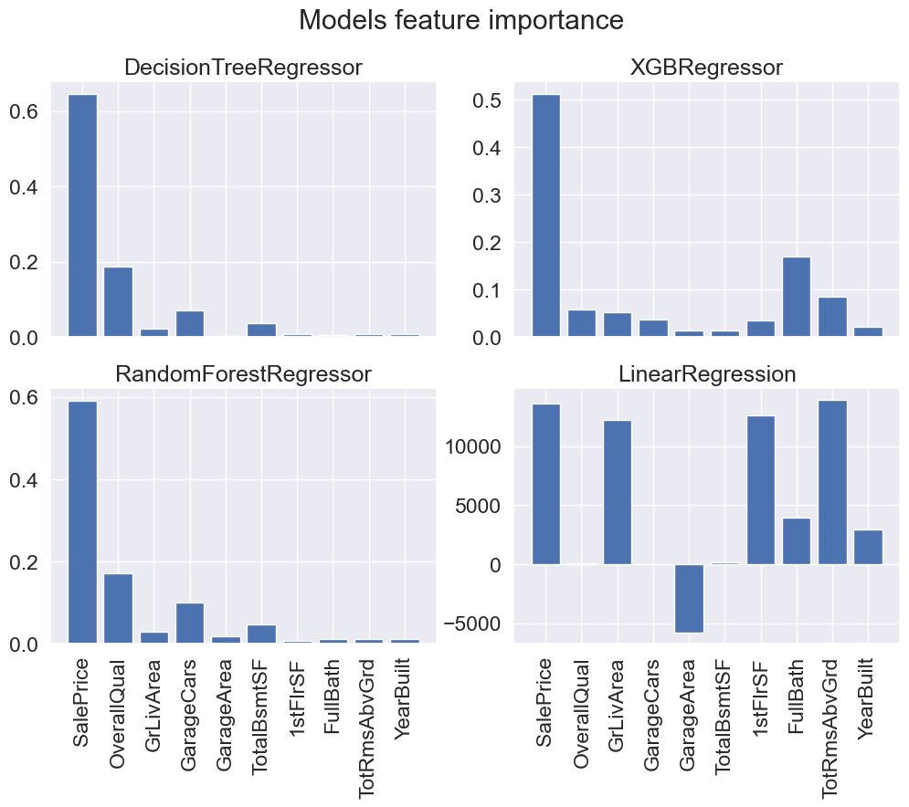

```python
# Create subplot figure
fig, axis = plt.subplots(2, 2, sharex=True, figsize=[12,8])
fig.suptitle('Models feature importance')

# Choose models to be used
models = [DecisionTreeRegressor(), RandomForestRegressor(), XGBRegressor()]
titles = ['DecisionTreeRegressor', 'RandomForestRegressor', 'XGBRegressor']
ax = [axis[0, 0], axis[1,0], axis[0,1]]

# Represent feature importance
for i in range(3):
    DT_feature_importance(models[i], X_enc, y, ax[i], features=cols, title=titles[i])

## Feature importance in a liner regression model
# Create and fit the model
model_LR = LinearRegression()
model_LR.fit(X_enc, y)

# Get importance values (these will be the coefficients)
importance = model_LR.coef_

# Create dataframe and plot
importance = pd.DataFrame(data=importance, index=list(X_enc.columns), columns=['importance'])
axis[1,1].bar(importance.index, importance['importance'])
axis[1,1].set_title('LinearRegression')
axis[1,1].set_xticklabels(cols, rotation=90);
```

We can say that all features can be important. Maybe 'FullBath' is not that important.

### **2.5 Outliers**

#### 2.5.1 Sale price univariate analysis

We standarize the data and look at the outer range data

```python
saleprice_scaled = StandardScaler().fit_transform(np.asarray(y).reshape(-1,1))
low_range = saleprice_scaled[saleprice_scaled[:,0].argsort()][:10]
high_range = saleprice_scaled[saleprice_scaled[:,0].argsort()][-10:]

print('outer range (low) of the distribution:')
print(low_range)
print('\nouter range (high) of the distribution:')
print(high_range)
```

```
outer range (low) of the distribution:
[[-1.83680482]
 [-1.83162147]
 [-1.79897015]
 [-1.78131397]
 [-1.77248588]
 [-1.62114718]
 [-1.61484141]
 [-1.58331251]
 [-1.58331251]
 [-1.57078923]]

outer range (high) of the distribution:
[[3.83965733]
 [4.05199813]
 [4.50806989]
 [4.72246638]
 [4.74240525]
 [5.07474502]
 [5.4369994 ]
 [5.60527542]
 [7.11866235]
 [7.24477793]]
```

We observe:

- Low range values are similar and not far from 0.
- High range values are far from 0 and there are two values above 7, which is very far from 0. We will be carefull with these two values.

#### 2.5.2 Bivariate analysis

We start by Ground living area

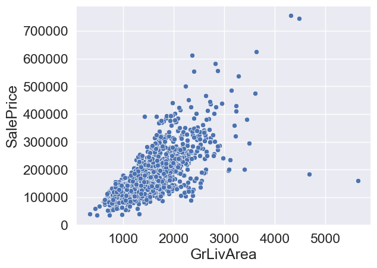

```python
var = 'GrLivArea'
sns.scatterplot(data=df_train, y='SalePrice', x=var);
```

- The two high GrLivArea values go away from the general trend. They possibly correspond to agricultural areas which in general have lower prices. We will consider them outliers and we will delete them.
- The two high sale price values that we said could be problematic. Although they are special cases, they seem to follow the general trend, so we will keep them.

```python
# Find high GrLivArea
df_train[df_train['GrLivArea'] > 4500]
```

|  | SalePrice | OverallQual | GrLivArea | GarageCars | TotalBsmtSF | FullBath | YearBuilt | ExterQual | BsmtQual | KitchenQual | GarageFinish |
| --- | --- | --- | --- | --- | --- | --- | --- | --- | --- | --- | --- |
| 523 | 184750 | 10 | 4676 | 3 | 3138 | 3 | 2007 | Ex | Ex | Ex | Fin |
| 1298 | 160000 | 10 | 5642 | 2 | 6110 | 2 | 2008 | Ex | Ex | Ex | Fin |

```python
# Delete points
df_train.drop(index=[523, 1298], inplace=True)
train.drop(index=[523, 1298], inplace=True)

assert df_train[df_train['GrLivArea'] > 4500].empty
```

We continue with Total basement squarefeets

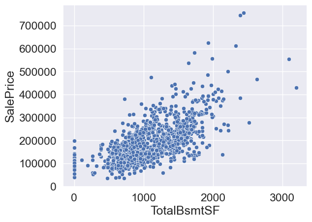

```python
var = 'TotalBsmtSF'
sns.scatterplot(data=df_train, y='SalePrice', x=var);
```

The points over 3000 TotalBsmtSF seem to be special cases but they are not so far from the general trend. We will keep them.

### **2.6 Normality, Homoscedasticity and linearity**

#### 2.6.1 Normality

We want our data to have a normal gaussian distribution

We start with sale price

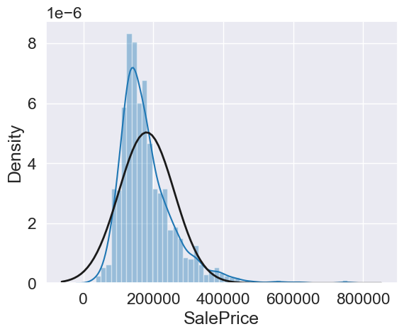

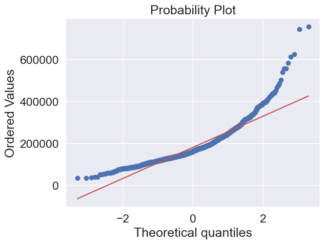

```python
var='SalePrice'
# Plot variable distribution compared to normal distribution
hist_normal(df_train[var])

# Normal probability plot
fig = plt.figure()
stats.probplot(df_train[var], plot=plt);
```

Sale price has not a normal distribution. It shows 'peakedness', positive skewness and does not follow the diagonal line.

We will try performing a logarithmic transformation

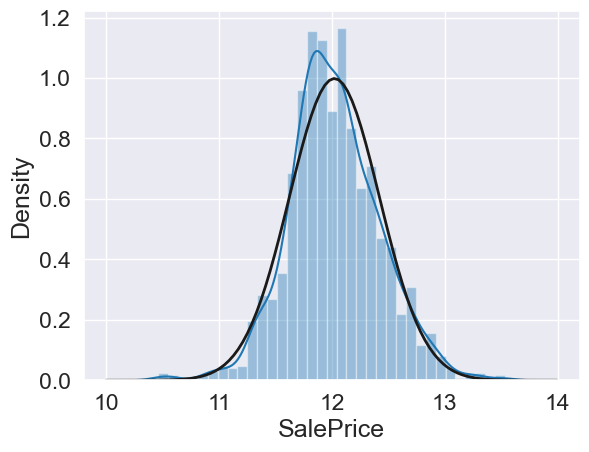

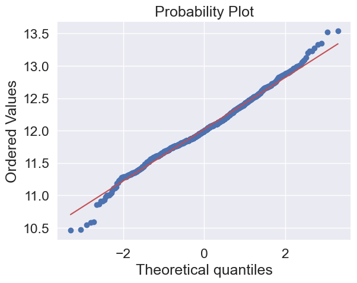

```python
# Logarithmic transformation
df_train[var] = np.log(df_train[var])

# Plot variable distribution compared to normal distribution
hist_normal(df_train[var])

# Normal probability plot
fig = plt.figure()
stats.probplot(df_train[var], plot=plt);
```

Now it fits the normal distribution.

We continue with Ground living area.

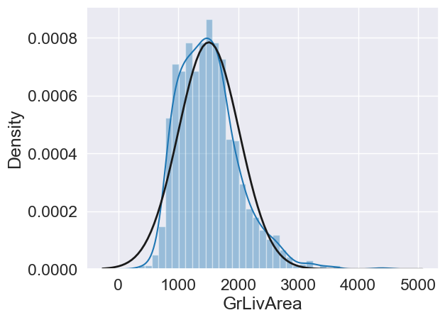

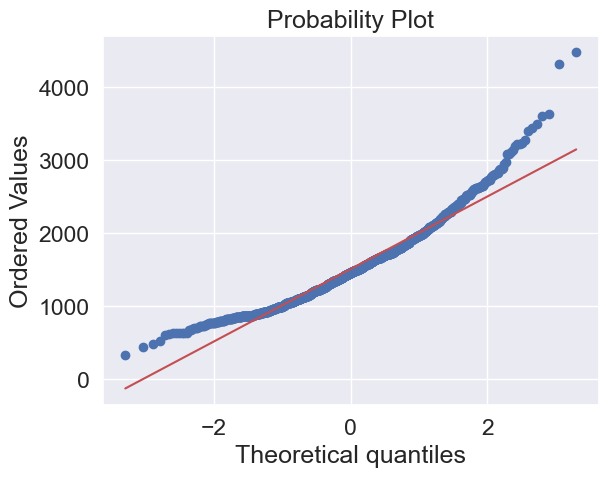

```python
var='GrLivArea'
# Plot variable distribution compared to normal distribution
hist_normal(df_train[var])

# Normal probability plot
fig = plt.figure()
stats.probplot(df_train[var], plot=plt);
```

We perform the same transformation as before.

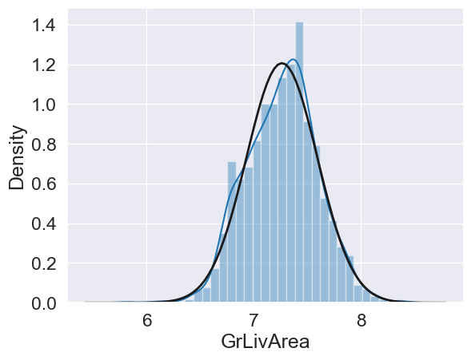

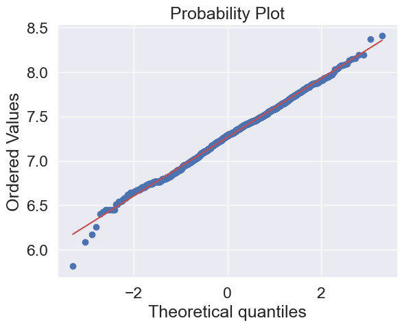

```python
# Logarithmic transformation
df_train[var] = np.log(df_train[var])

# Plot variable distribution compared to normal distribution
hist_normal(df_train[var])

# Normal probability plot
fig = plt.figure()
stats.probplot(df_train[var], plot=plt);
```

Total basement squarefeets.

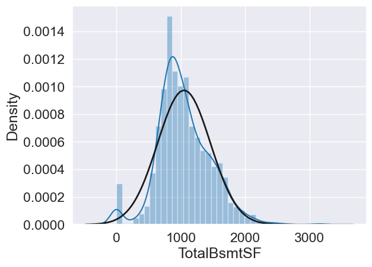

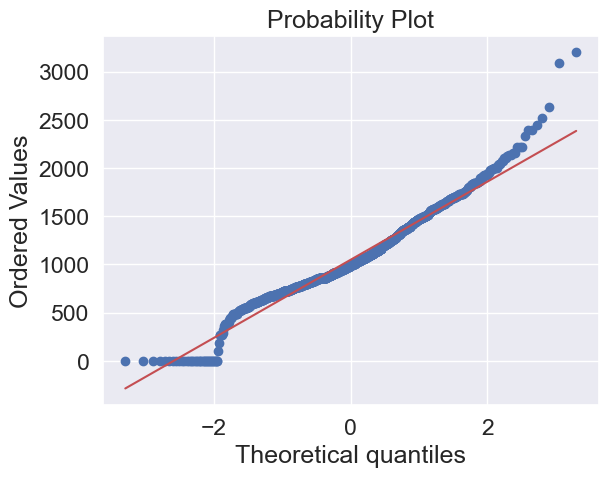

```python
var='TotalBsmtSF'
# Plot variable distribution compared to normal distribution
hist_normal(df_train[var])

# Normal probability plot
fig = plt.figure()
stats.probplot(df_train[var], plot=plt);
```

This distribution is different than the previous ones. In general it presents skewedness, and we see a large number of cero values which refer to houses without basement.

We can not perform logarithmic transformation to values equal cero. To solve this, we will create a variable which accounts for no basement. This way we will not loose this information. And then we will perform the logarithmic transformation to values different from cero.

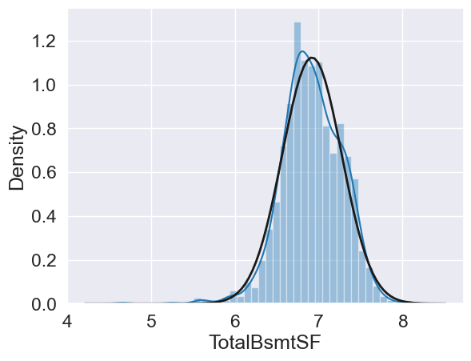

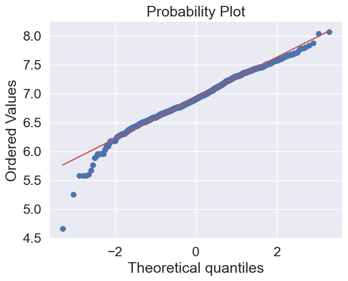

```python
# Basement feature
df_train['HasBsmt'] = df_train['TotalBsmtSF'] > 0

# Logarithmic transformation
df_train.loc[df_train['HasBsmt'] == 1, 'TotalBsmtSF'] = np.log(df_train['TotalBsmtSF'])

## Plots
# Plot variable distribution compared to normal distribution
hist_normal(df_train[df_train['TotalBsmtSF']>0]['TotalBsmtSF'])

# Normal probability plot
fig = plt.figure()
stats.probplot(df_train[df_train['TotalBsmtSF']>0]['TotalBsmtSF'], plot=plt);
```

#### 2.6.2 Homoscedasticity

In this section we look for dependent variables to exhibit equal levels of variance across the range of predictor variable. This is necessary if we want the error term to be the same across all values of the independent variables.

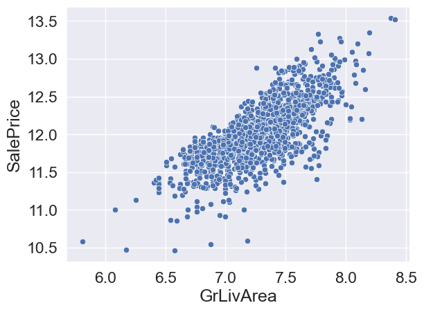

```python
sns.scatterplot(data=df_train, x='GrLivArea', y='SalePrice');
```

We see that after the logarithmic transformation this scatter plot does not show a conic shape anymore. Having a conic (or diamond) shape would mean lack of homoscedasticity.

Now we check 'TotalBsmtSF' and 'SalePrice'.

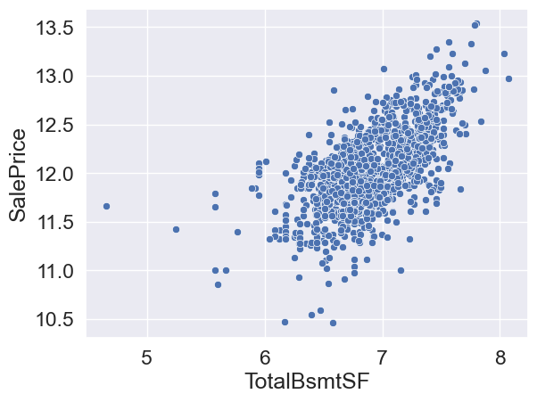

```python
sns.scatterplot(x=df_train[df_train['TotalBsmtSF']>0]['TotalBsmtSF'], y=df_train[df_train['TotalBsmtSF']>0]['SalePrice']);
```

In general 'SalePrice' shows the same level of variance across the range of 'TotalBsmtSF'.

## **3. Predictive model: Linear regression**

We create a predictive model based on linear regression.

We encode categorical features and usea k-fold cross validation to tune two parameters: polynomial degree of the features and regularization parameter.

```
Polynomial degree: 1
=========================
MSE_train: 0.0116, MSE_train_std: 0.0002
MSE_cv: 0.0118, MSE_cv_std: 0.0002

Polynomial degree: 2
=========================
MSE_train: 0.0099, MSE_train_std: 0.0002
MSE_cv: 0.0113, MSE_cv_std: 0.0002

Polynomial degree: 3
=========================
MSE_train: 0.0084, MSE_train_std: 0.0001
MSE_cv: 0.0133, MSE_cv_std: 0.0001
```

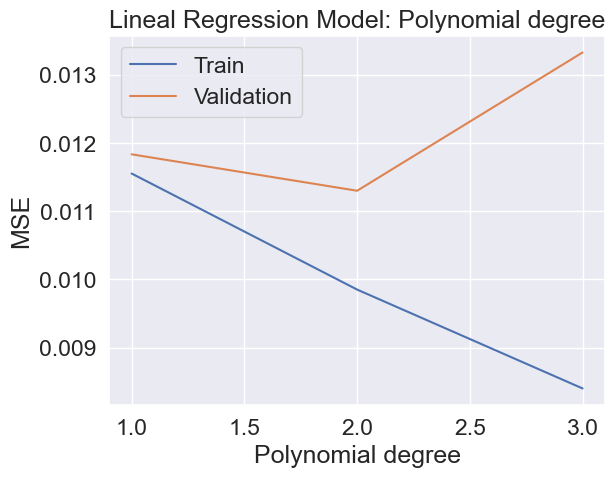

```python
# Ordinal encoding
df_train_enc = df_train.copy()
oe = OrdinalEncoder(categories=[['Fa','TA', 'Gd', 'Ex'], ['NA','Po','Fa','TA', 'Gd', 'Ex'], ['Po','Fa','TA', 'Gd', 'Ex'], ['NA', 'Unf', 'RFn', 'Fin']])
df_train_enc[['ExterQual', 'BsmtQual', 'KitchenQual', 'GarageFinish']] = oe.fit_transform(df_train_enc[['ExterQual', 'BsmtQual', 'KitchenQual', 'GarageFinish']])

# Separate X and y
y = df_train_enc['SalePrice']
X = df_train_enc.drop('SalePrice', axis=1)

# prepare cross-validation
kfold = KFold(n_splits=10, shuffle=True, random_state=1)

# Iterate for different features polynomial degrees
MSE_train_list = []
MSE_cv_list = []

max_deg = 3
for degree in range(1, max_deg + 1):

    # Apply model with k-fold cross-validation
    mse_train_klist = []
    mse_cv_klist = []

    for i, (id_train, cv) in enumerate(kfold.split(df_train_enc)):

        # Define datasets
        X_train = X.iloc[id_train]
        y_train = y.iloc[id_train]
        assert X_train.shape[0] == y_train.shape[0]

        X_cv = X.iloc[cv]
        y_cv = y.iloc[cv]
        assert X_cv.shape[0] == y_cv.shape[0]


        # Add polinomial features
        poly= PolynomialFeatures(degree, include_bias=False)
        X_train_mapped = poly.fit_transform(X_train)
        X_cv_mapped = poly.fit_transform(X_cv)

        # Feature scaling
        scaler = StandardScaler()
        X_train_mapped_sc = scaler.fit_transform(X_train_mapped)
        X_cv_mapped_sc = scaler.transform(X_cv_mapped)

        # Apply the model
        model = Ridge(alpha=0.01)
        model.fit(X_train_mapped_sc, y_train)

        # Calculate predictions
        y_train_p = model.predict(X_train_mapped_sc)
        y_cv_p = model.predict(X_cv_mapped_sc)

        # Calculate MSE
        mse_train = mean_squared_error(y_train, y_train_p) / 2
        mse_cv = mean_squared_error(y_cv, y_cv_p) / 2

        # Save MSE results
        mse_train_klist.append(mse_train)
        mse_cv_klist.append(mse_cv)


    # Mean MSE_train and MSE_cv folds
    MSE_train = np.mean(mse_train_klist)
    MSE_cv = np.mean(mse_cv_klist)
    MSE_train_list.append(MSE_train)
    MSE_cv_list.append(MSE_cv)

    # Std of MSE's
    MSE_train_std = np.std(mse_train_klist)
    MSE_cv_std = np.std(mse_train_klist)

    print('\nPolynomial degree:', degree)
    print('=========================')
    print('MSE_train: %.4f, MSE_train_std: %.4f' % (MSE_train, MSE_train_std))
    print('MSE_cv: %.4f, MSE_cv_std: %.4f' % (MSE_cv,  MSE_cv_std))

# Plot results
plt.plot(range(1, max_deg + 1), MSE_train_list, label='Train')
plt.plot(range(1, max_deg + 1), MSE_cv_list, label='Validation')
plt.legend()
plt.xlabel('Polynomial degree')
plt.ylabel('MSE')
plt.title('Lineal Regression Model: Polynomial degree')
```

We get the best fit with degree: 2

Now we tune the regularization parameter.

```
Alpha: 0
=========================
MSE_train: 0.009892, MSE_train_std: 0.0002
MSE_cv: 0.011400, MSE_cv_std: 0.0002

Alpha: 0.005
=========================
MSE_train: 0.009833, MSE_train_std: 0.0002
MSE_cv: 0.011307, MSE_cv_std: 0.0002

Alpha: 0.01
=========================
MSE_train: 0.009851, MSE_train_std: 0.0002
MSE_cv: 0.011300, MSE_cv_std: 0.0002

Alpha: 0.015
=========================
MSE_train: 0.009868, MSE_train_std: 0.0002
MSE_cv: 0.011302, MSE_cv_std: 0.0002

Alpha: 0.03
=========================
MSE_train: 0.009911, MSE_train_std: 0.0002
MSE_cv: 0.011317, MSE_cv_std: 0.0002

Alpha: 0.06
=========================
MSE_train: 0.009971, MSE_train_std: 0.0002
MSE_cv: 0.011340, MSE_cv_std: 0.0002

Alpha: 0.1
=========================
MSE_train: 0.010024, MSE_train_std: 0.0002
MSE_cv: 0.011354, MSE_cv_std: 0.0002
```

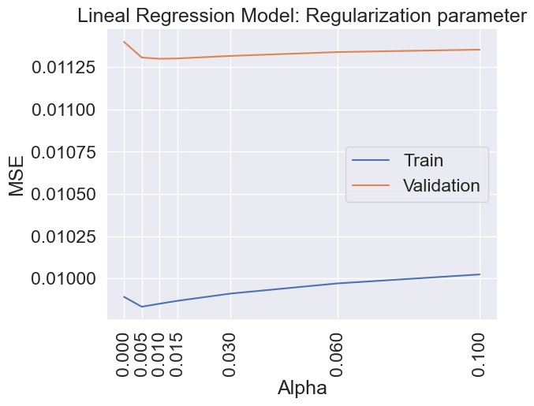

```python
degree = 2

# Iterate for different regulariztion parameters "alpha"
MSE_train_list = []
MSE_cv_list = []

alpha_list = [0, 0.005, 0.01, 0.015, 0.03, 0.06, 0.1]

for alpha in alpha_list:

    # Apply model with k-fold cross-validation
    mse_train_klist = []
    mse_cv_klist = []

    for i, (id_train, cv) in enumerate(kfold.split(df_train_enc)):

        # Define datasets
        X_train = X.iloc[id_train]
        y_train = y.iloc[id_train]
        assert X_train.shape[0] == y_train.shape[0]

        X_cv = X.iloc[cv]
        y_cv = y.iloc[cv]
        assert X_cv.shape[0] == y_cv.shape[0]


        # Add polinomial features
        poly= PolynomialFeatures(degree, include_bias=False)
        X_train_mapped = poly.fit_transform(X_train)
        X_cv_mapped = poly.fit_transform(X_cv)

        # Feature scaling
        scaler = StandardScaler()
        X_train_mapped_sc = scaler.fit_transform(X_train_mapped)
        X_cv_mapped_sc = scaler.transform(X_cv_mapped)

        # Apply the model
        model = Ridge(alpha=alpha)
        model.fit(X_train_mapped_sc, y_train)

        # Calculate predictions
        y_train_p = model.predict(X_train_mapped_sc)
        y_cv_p = model.predict(X_cv_mapped_sc)

        # Calculate MSE
        mse_train = mean_squared_error(y_train, y_train_p) / 2
        mse_cv = mean_squared_error(y_cv, y_cv_p) / 2

        # Save MSE results
        mse_train_klist.append(mse_train)
        mse_cv_klist.append(mse_cv)

    # Mean MSE_train and MSE_cv folds
    MSE_train = np.mean(mse_train_klist)
    MSE_cv = np.mean(mse_cv_klist)
    MSE_train_list.append(MSE_train)
    MSE_cv_list.append(MSE_cv)

    # Std of MSE's
    MSE_train_std = np.std(mse_train_klist)
    MSE_cv_std = np.std(mse_train_klist)

    print('\nAlpha:', alpha)
    print('=========================')
    print('MSE_train: %.6f, MSE_train_std: %.4f' % (MSE_train, MSE_train_std))
    print('MSE_cv: %.6f, MSE_cv_std: %.4f' % (MSE_cv,  MSE_cv_std))

# Plot results
plt.plot(alpha_list, MSE_train_list, label='Train')
plt.plot(alpha_list, MSE_cv_list, label='Validation')
plt.legend()
plt.xlabel('Alpha')
plt.xticks(alpha_list, rotation=90)
plt.ylabel('MSE')
plt.title('Lineal Regression Model: Regularization parameter')
```

We get the best performance with:

- Polynomial degree: 2
- Regularization parameter (alpha): 0.01

## **4. Test set**

```python
general_info(test, 'Test set')
```

```
Test set
-----------------------------------------------
Shape: (1459, 80)
Duplicates: 0
Null values: 7878

Columns:
0-10: Id, MSSubClass, MSZoning, LotFrontage, LotArea, Street, Alley, LotShape, LandContour, Utilities
10-20: LotConfig, LandSlope, Neighborhood, Condition1, Condition2, BldgType, HouseStyle, OverallQual, OverallCond, YearBuilt
20-30: YearRemodAdd, RoofStyle, RoofMatl, Exterior1st, Exterior2nd, MasVnrType, MasVnrArea, ExterQual, ExterCond, Foundation
30-40: BsmtQual, BsmtCond, BsmtExposure, BsmtFinType1, BsmtFinSF1, BsmtFinType2, BsmtFinSF2, BsmtUnfSF, TotalBsmtSF, Heating
40-50: HeatingQC, CentralAir, Electrical, 1stFlrSF, 2ndFlrSF, LowQualFinSF, GrLivArea, BsmtFullBath, BsmtHalfBath, FullBath
50-60: HalfBath, BedroomAbvGr, KitchenAbvGr, KitchenQual, TotRmsAbvGrd, Functional, Fireplaces, FireplaceQu, GarageType, GarageYrBlt
60-70: GarageFinish, GarageCars, GarageArea, GarageQual, GarageCond, PavedDrive, WoodDeckSF, OpenPorchSF, EnclosedPorch, 3SsnPorch
70-79: ScreenPorch, PoolArea, PoolQC, Fence, MiscFeature, MiscVal, MoSold, YrSold, SaleType, SaleCondition
```

[output cut: 93 more lines]

### **4.1 Fixing data**

We perform data cleaning and the same transformations we did on the train set:

1. We fix missing data

```python
# We drop same columns as in the training set
test.drop(columns=['PoolQC', 'MiscFeature', 'Alley', 'Fence', 'MasVnrType', 'FireplaceQu', 'LotFrontage'], inplace=True)
```

```python
missing_data(test).head(25)
```

|  | Total_NaN | Percent_NaN | Total_null | Percent_null |
| --- | --- | --- | --- | --- |
| GarageYrBlt | 78 | 0.053461 | 78 | 0.053461 |
| GarageFinish | 78 | 0.053461 | 78 | 0.053461 |
| GarageQual | 78 | 0.053461 | 78 | 0.053461 |
| GarageCond | 78 | 0.053461 | 78 | 0.053461 |
| GarageType | 76 | 0.052090 | 76 | 0.052090 |
| BsmtCond | 45 | 0.030843 | 45 | 0.030843 |
| BsmtExposure | 44 | 0.030158 | 44 | 0.030158 |
| BsmtQual | 44 | 0.030158 | 44 | 0.030158 |
| BsmtFinType2 | 42 | 0.028787 | 42 | 0.028787 |
| BsmtFinType1 | 42 | 0.028787 | 42 | 0.028787 |
| MasVnrArea | 15 | 0.010281 | 15 | 0.010281 |
| MSZoning | 4 | 0.002742 | 4 | 0.002742 |
| Functional | 2 | 0.001371 | 2 | 0.001371 |
| BsmtHalfBath | 2 | 0.001371 | 2 | 0.001371 |
| Utilities | 2 | 0.001371 | 2 | 0.001371 |
| BsmtFullBath | 2 | 0.001371 | 2 | 0.001371 |
| Exterior2nd | 1 | 0.000685 | 1 | 0.000685 |
| BsmtFinSF1 | 1 | 0.000685 | 1 | 0.000685 |
| BsmtFinSF2 | 1 | 0.000685 | 1 | 0.000685 |
| BsmtUnfSF | 1 | 0.000685 | 1 | 0.000685 |
| TotalBsmtSF | 1 | 0.000685 | 1 | 0.000685 |
| KitchenQual | 1 | 0.000685 | 1 | 0.000685 |
| Exterior1st | 1 | 0.000685 | 1 | 0.000685 |
| GarageCars | 1 | 0.000685 | 1 | 0.000685 |
| GarageArea | 1 | 0.000685 | 1 | 0.000685 |

Houses without basement will have 'NA' as 'BsmtX' features

```python
mask = test['TotalBsmtSF'] == 0
basement = ['BsmtQual', 'BsmtCond', 'BsmtExposure', 'BsmtFinType1', 'BsmtFinSF1',
       'BsmtFinType2', 'BsmtFinSF2', 'BsmtUnfSF', 'TotalBsmtSF',
       'BsmtFullBath', 'BsmtHalfBath']
test.loc[mask, basement] = test.loc[mask, basement].fillna('NA')
```

Houses without garage will have 'NA' as 'GarageFinish' and 'GarageCars'

```python
mask = test['GarageArea'] == 0
garage = [test.columns[ele] for ele in range(54, 61)]

test.loc[mask, garage] = test.loc[mask, garage].fillna('NA')
```

We look at the missing values in the selected features

```python
selected_cols.remove('SalePrice')

missing_data(test[selected_cols])
```

|  | Total_NaN | Percent_NaN | Total_null | Percent_null |
| --- | --- | --- | --- | --- |
| BsmtQual | 3 | 0.002056 | 3 | 0.002056 |
| GarageFinish | 2 | 0.001371 | 2 | 0.001371 |
| GarageCars | 1 | 0.000685 | 1 | 0.000685 |
| TotalBsmtSF | 1 | 0.000685 | 1 | 0.000685 |
| KitchenQual | 1 | 0.000685 | 1 | 0.000685 |
| OverallQual | 0 | 0.000000 | 0 | 0.000000 |
| GrLivArea | 0 | 0.000000 | 0 | 0.000000 |
| FullBath | 0 | 0.000000 | 0 | 0.000000 |
| YearBuilt | 0 | 0.000000 | 0 | 0.000000 |
| ExterQual | 0 | 0.000000 | 0 | 0.000000 |

```python
mask = test['BsmtQual'].isnull()
test[mask][basement]
```

|  | BsmtQual | BsmtCond | BsmtExposure | BsmtFinType1 | BsmtFinSF1 | BsmtFinType2 | BsmtFinSF2 | BsmtUnfSF | TotalBsmtSF | BsmtFullBath | BsmtHalfBath |
| --- | --- | --- | --- | --- | --- | --- | --- | --- | --- | --- | --- |
| 660 | NaN | NaN | NaN | NaN | NaN | NaN | NaN | NaN | NaN | NaN | NaN |
| 757 | NaN | Fa | No | Unf | 0.0 | Unf | 0.0 | 173.0 | 173.0 | 0.0 | 0.0 |
| 758 | NaN | TA | No | Unf | 0.0 | Unf | 0.0 | 356.0 | 356.0 | 0.0 | 0.0 |

Row 660: We have no basement data for row 660. We fill 'BsmtQual' with 'NA' and 'TotalBsmtArea with 0.

Rows 757 and 758: We fill 'BsmtQual' with information from 'BsmtCond'

```python
test.loc[660, 'BsmtQual'] = 'NA'
test.loc[660, 'TotalBsmtSF'] = 0
test.loc[757, basement] = test.loc[757, basement].fillna('Fa')
test.loc[758, basement] = test.loc[758, basement].fillna('TA')
```

Now we deal with the GarageX missing values

```python
mask = test['GarageFinish'].isnull()
test[mask][garage]
```

|  | GarageType | GarageYrBlt | GarageFinish | GarageCars | GarageArea | GarageQual | GarageCond |
| --- | --- | --- | --- | --- | --- | --- | --- |
| 666 | Detchd | NaN | NaN | 1.0 | 360.0 | NaN | NaN |
| 1116 | Detchd | NaN | NaN | NaN | NaN | NaN | NaN |

Row 666: We do not know if the garage is finished or not. We will fill 'GarageFinish' with the most common value.

Row 1116: In 'GarageType' it says there is a detached garage, but there is no additional information. We will fill 'GarageFinish' with the most common value and also 'GarageCars'.

```python
test.loc[666, 'GarageFinish'] = test.GarageFinish.value_counts().index[0]
test.loc[1116, 'GarageFinish'] = test.GarageFinish.value_counts().index[0]
test.loc[1116, 'GarageCars'] = test.GarageCars.value_counts().index[0]
```

And finally, the KitchenQual missing value. We will fill this value with the average 'TA'

```python
mask = test['KitchenQual'].isnull()
idx = test[mask].index
test.loc[idx, 'KitchenQual'] = 'TA'

# assert there are no missing values
assert test[selected_cols].isnull().sum().sum() == 0
```

2. Create a dataframe only with the selcted features

```python
df_test = test[selected_cols]
```

3. 'GrLivArea' and 'TotalBsmtSF' logarithmic transformations and 'HasBsmt' feature

```python
# 'GrLivArea' logarithmic transformation
df_test['GrLivArea'] = np.log(df_test['GrLivArea'])

# Basement feature
df_test['HasBsmt'] = df_test['TotalBsmtSF'] > 0

# 'TotalBsmtSF' logarithmic transformation
df_test.loc[df_test['HasBsmt'] == 1, 'TotalBsmtSF'] = np.log(df_test['TotalBsmtSF'])
```

### **4.2 Apply the model**

We train a linear regression model using the train set and the parameters tuned before, and apply this model to the test set.

To do so, we need to ordinal encode the categorical data, add polynomial features and perform feature scaling.

```python
# Ordinal encoding
df_test_enc = df_test.copy()
# oe = OrdinalEncoder(categories=[['Fa','TA', 'Gd', 'Ex'], ['NA','Po','Fa','TA', 'Gd', 'Ex'], ['Po','Fa','TA', 'Gd', 'Ex'], ['NA', 'Unf', 'RFn', 'Fin']])
df_test_enc[['ExterQual', 'BsmtQual', 'KitchenQual', 'GarageFinish']] = oe.transform(df_test_enc[['ExterQual', 'BsmtQual', 'KitchenQual', 'GarageFinish']])

degree = 2
alpha = 0.01
# Add polinomial features
poly= PolynomialFeatures(degree, include_bias=False)
X_mapped = poly.fit_transform(X)
test_mapped = poly.fit_transform(df_test_enc)

# Feature scaling
scaler = StandardScaler()
X_mapped_sc = scaler.fit_transform(X_mapped)
test_mapped_sc = scaler.transform(test_mapped)

# Apply the model
model = Ridge(alpha=alpha).fit(X_mapped_sc, y)
model_prediction = model.predict(test_mapped_sc)
```

### **4.3 Submission file**

```python
# Reverse logarithmic transformation
prediction = np.exp(model_prediction)

# Submit results
submission = pd.DataFrame({'Id': test['Id'], 'SalePrice': prediction})
submission.to_csv('results.csv', index=False)
```

```python
# We save this notebook as an html file
!jupyter nbconvert house_prices.ipynb --to html
```

```
[NbConvertApp] Converting notebook house_prices.ipynb to html
[NbConvertApp] WARNING | Alternative text is missing on 28 image(s).
[NbConvertApp] Writing 2750644 bytes to house_prices.html
```